# Analysis of factors affecting red wine quality

Ruofan Zang

August 17, 2019

# Introduction

Nowadays, red wine is increasingly enjoyed by a wider range of consumers. With its growth, the quality of red wine is becoming more and more important. It is better for people who like drinking red wine to understand the efect factors of red wine quality and know how to judge whether or not it is the one with good quality.

In this project, we will figure out which attributes affect the quality of red wine significantly.

The data set is available from this [link](https://www.kaggle.com/uciml/red-wine-quality-cortez-et-al-2009) in kaggle and its original source is the UCI Machine Learning Repository, you can find the data set [here](https://archive.ics.uci.edu/ml/datasets/wine+quality) from the source. The goal of this data set and our model is to determine the red wine quality, so the outcome of the project is the quality of red wine and we will display the quality quantitatively as the quality score. The detaied explanation of the data set is as follows:

- fixed acidity: most acids involved with wine or fixed or nonvolatile, *numeric variable* (g/L)
- volatile acidity: the amount of acetic acid in wine, which at too high of levels can lead to an unpleasant, vinegar taste, *numeric variable* (g/L)
- citric acid: found in small quantities, citric acid can add ‘freshness’ and flavor to wines, *numeric variable* (g/L)
- residual sugar: the amount of sugar remaining after fermentation stops, *numeric variable* (g/L)
- chlorides: the amount of salt in the wine, *numeric variable* (g/L)
- free sulfur dioxide: the free form of SO2 exists in equilibrium between molecular SO2 and bisulfite ion; it prevents microbial growth and the oxidation of wine, *numeric variable*
- total sulfur dioxide: amount of free and bound forms of S02, *numeric variable*
- density: the density of water is close to that of water depending on the percent alcohol and sugar content, *numeric variable*
- pH: describes how acidic or basic a wine is on a scale from 0 (very acidic) to 14 (very basic), *numeric variable*
- sulphates: a wine additive which can contribute to sulfur dioxide gas levels, which acts as an antimicrobial and antioxidant, *numeric variable*
- alcohol: the percent alcohol content of the wine, *numeric variable*
- quality: output variable (based on sensory data, score between 0 and 10), *integer variable*

## Import and inspect

```r
data <- read.csv('C:/Users/RUOFAN/Documents/R/course/winequality_red.csv')
```

```r
# display the row number of the data set
nrow(data)
```

```
## [1] 1599
```

```r
# display the column number of the data set
ncol(data)
```

```
## [1] 12
```

```r
# display the first few rows and columns
head(data)
```

```
##   fixed.acidity volatile.acidity citric.acid residual.sugar chlorides
## 1           7.4             0.70        0.00            1.9     0.076
## 2           7.8             0.88        0.00            2.6     0.098
## 3           7.8             0.76        0.04            2.3     0.092
## 4          11.2             0.28        0.56            1.9     0.075
## 5           7.4             0.70        0.00            1.9     0.076
## 6           7.4             0.66        0.00            1.8     0.075
##   free.sulfur.dioxide total.sulfur.dioxide density   pH sulphates alcohol
## 1                  11                   34  0.9978 3.51      0.56     9.4
## 2                  25                   67  0.9968 3.20      0.68     9.8
## 3                  15                   54  0.9970 3.26      0.65     9.8
## 4                  17                   60  0.9980 3.16      0.58     9.8
## 5                  11                   34  0.9978 3.51      0.56     9.4
## 6                  13                   40  0.9978 3.51      0.56     9.4
##   quality
## 1       5
## 2       5
## 3       5
## 4       6
## 5       5
## 6       5
```

```r
# display types and structure of each column
str(data)
```

```
## 'data.frame':    1599 obs. of  12 variables:
##  $ fixed.acidity       : num  7.4 7.8 7.8 11.2 7.4 7.4 7.9 7.3 7.8 7.5 ...
##  $ volatile.acidity    : num  0.7 0.88 0.76 0.28 0.7 0.66 0.6 0.65 0.58 0.5 ...
##  $ citric.acid         : num  0 0 0.04 0.56 0 0 0.06 0 0.02 0.36 ...
##  $ residual.sugar      : num  1.9 2.6 2.3 1.9 1.9 1.8 1.6 1.2 2 6.1 ...
##  $ chlorides           : num  0.076 0.098 0.092 0.075 0.076 0.075 0.069 0.065 0.073 0.071 ...
##  $ free.sulfur.dioxide : num  11 25 15 17 11 13 15 15 9 17 ...
##  $ total.sulfur.dioxide: num  34 67 54 60 34 40 59 21 18 102 ...
##  $ density             : num  0.998 0.997 0.997 0.998 0.998 ...
##  $ pH                  : num  3.51 3.2 3.26 3.16 3.51 3.51 3.3 3.39 3.36 3.35 ...
##  $ sulphates           : num  0.56 0.68 0.65 0.58 0.56 0.56 0.46 0.47 0.57 0.8 ...
##  $ alcohol             : num  9.4 9.8 9.8 9.8 9.4 9.4 9.4 10 9.5 10.5 ...
##  $ quality             : int  5 5 5 6 5 5 5 7 7 5 ...
```

We can see that all the variables in this dataset are numeric variables.

```r
# check whether there are missing values in each column
colSums(is.na(data))
```

```
##        fixed.acidity     volatile.acidity          citric.acid
##                    0                    0                    0
##       residual.sugar            chlorides  free.sulfur.dioxide
##                    0                    0                    0
## total.sulfur.dioxide              density                   pH
##                    0                    0                    0
##            sulphates              alcohol              quality
##                    0                    0                    0
```

```r
red_wine <- na.omit(data)
```

We can see that there does not have any missing data in this dataset.

```r
# all the columns contain numeric variables, we don't have categorical values
# we don't have missing values
summary(red_wine)
```

```
##  fixed.acidity   volatile.acidity  citric.acid    residual.sugar
##  Min.   : 4.60   Min.   :0.1200   Min.   :0.000   Min.   : 0.900
##  1st Qu.: 7.10   1st Qu.:0.3900   1st Qu.:0.090   1st Qu.: 1.900
##  Median : 7.90   Median :0.5200   Median :0.260   Median : 2.200
##  Mean   : 8.32   Mean   :0.5278   Mean   :0.271   Mean   : 2.539
##  3rd Qu.: 9.20   3rd Qu.:0.6400   3rd Qu.:0.420   3rd Qu.: 2.600
##  Max.   :15.90   Max.   :1.5800   Max.   :1.000   Max.   :15.500
##    chlorides       free.sulfur.dioxide total.sulfur.dioxide
##  Min.   :0.01200   Min.   : 1.00       Min.   :  6.00
##  1st Qu.:0.07000   1st Qu.: 7.00       1st Qu.: 22.00
##  Median :0.07900   Median :14.00       Median : 38.00
##  Mean   :0.08747   Mean   :15.87       Mean   : 46.47
##  3rd Qu.:0.09000   3rd Qu.:21.00       3rd Qu.: 62.00
##  Max.   :0.61100   Max.   :72.00       Max.   :289.00
##     density             pH          sulphates         alcohol
##  Min.   :0.9901   Min.   :2.740   Min.   :0.3300   Min.   : 8.40
##  1st Qu.:0.9956   1st Qu.:3.210   1st Qu.:0.5500   1st Qu.: 9.50
##  Median :0.9968   Median :3.310   Median :0.6200   Median :10.20
##  Mean   :0.9967   Mean   :3.311   Mean   :0.6581   Mean   :10.42
##  3rd Qu.:0.9978   3rd Qu.:3.400   3rd Qu.:0.7300   3rd Qu.:11.10
##  Max.   :1.0037   Max.   :4.010   Max.   :2.0000   Max.   :14.90
##     quality
##  Min.   :3.000
##  1st Qu.:5.000
##  Median :6.000
##  Mean   :5.636
##  3rd Qu.:6.000
##  Max.   :8.000
```

# Feature Engineering: Part I

The target variable in this project is **quality**.

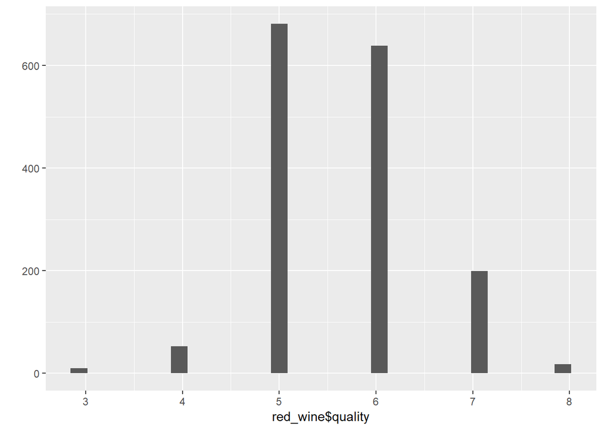

```r
library(ggplot2)
qplot(red_wine$quality)
```

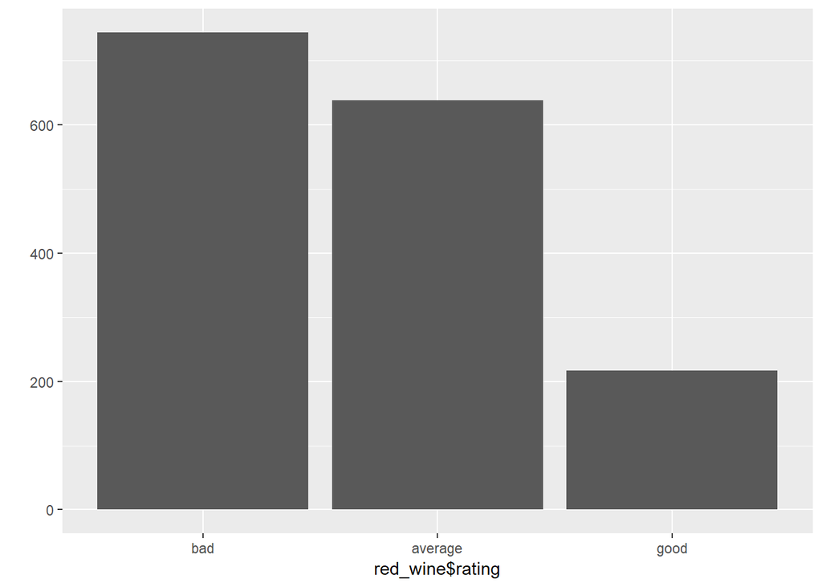

```r
red_wine$rating <- ifelse(red_wine$quality < 6, 'bad', ifelse(red_wine$quality == 6, 'average', 'good'))
red_wine$rating <- ordered(red_wine$rating, levels = c('bad', 'average', 'good'))
qplot(red_wine$rating)
```

Because all the variables are numeric, I will mainly use histogram to explore each variable.

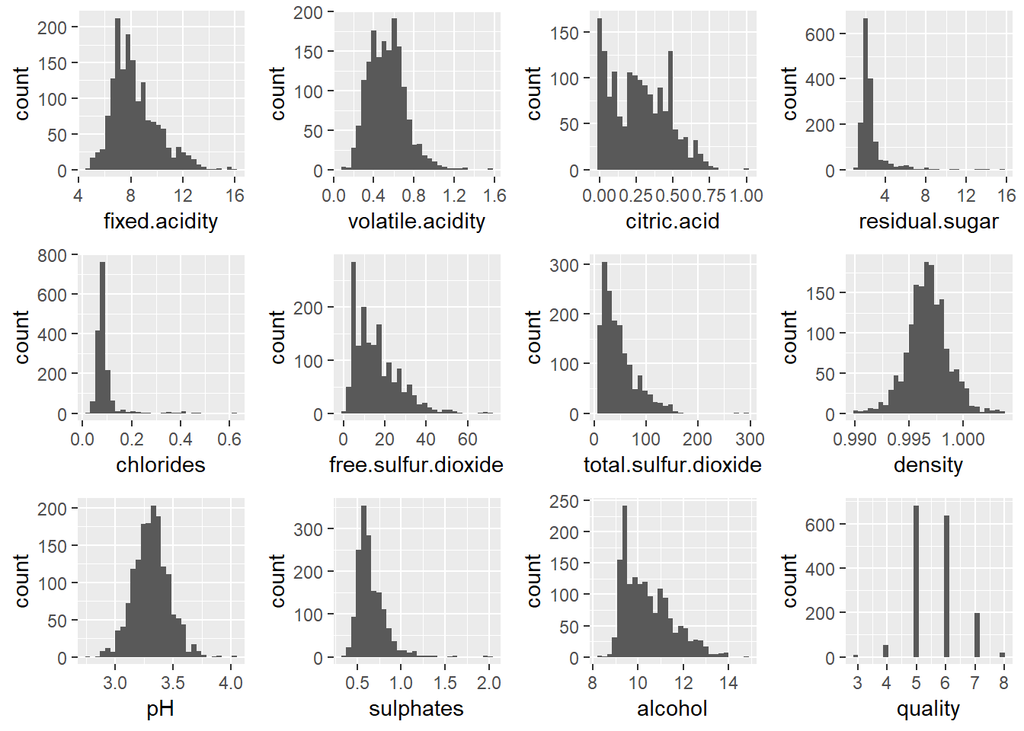

```r
library(gridExtra)
grid.arrange(qplot(red_wine$fixed.acidity, xlab = 'fixed.acidity', ylab = 'count'),
             qplot(red_wine$volatile.acidity,  xlab = 'volatile.acidity', ylab = 'count'),
             qplot(red_wine$citric.acid, xlab = 'citric.acid', ylab = 'count'),
             qplot(red_wine$residual.sugar, xlab = 'residual.sugar', ylab = 'count'),
             qplot(red_wine$chlorides, xlab = 'chlorides', ylab = 'count'),
             qplot(red_wine$free.sulfur.dioxide, xlab = 'free.sulfur.dioxide', ylab = 'count'),
             qplot(red_wine$total.sulfur.dioxide, xlab = 'total.sulfur.dioxide', ylab = 'count'),
             qplot(red_wine$density, xlab = 'density', ylab = 'count'),
             qplot(red_wine$pH, xlab = 'pH', ylab = 'count'),
             qplot(red_wine$sulphates, xlab = 'sulphates', ylab = 'count'),
             qplot(red_wine$alcohol, xlab = 'alcohol', ylab = 'count'),
             qplot(red_wine$quality, xlab = 'quality', ylab = 'count'),
             ncol = 4)
```

**Density and pH are almost normally distributed.** Fixed and volatile acidity, free and total sulfur dioxide, sulphates, and alcohol seem to be long-tailed (skewed on one side). Residual sugar and chlorides have extreme outliers. Citric acid has a large number of zero values.

**Fixed Acidity**